# Little Rock Child Maltreatment: Predictive Analysis

UA Research Team

November 19, 2019

# 1 Predict Phase

## 1.1 Motivation

Figure 1.1a shows the count of maltreatment events between 2015 and 2018 by census tracts and it shows that not all areas are affected by maltreatment in the same manner. A key question is how do we ensure that our limited child welfare resources are properly deployed to the communities where they are needed most?

To understand which communities have the greatest need, we must first determine where child maltreatment is likely to occur. While there are a host of individual, family, and household level factors associated with child maltreatment, research shows that community and social factors play an important role in understanding where maltreatment may occur.[^2] At high densities, externalities associated with these ‘neighborhood effects’ can influence peers in close proximity.[^3]

These spillover effects appear as maltreatment event clusters, as visualized in Figure 1.1b, which maps the rate of child maltreatment events in Little Rock, AR between 2015 and 2018.[^4] Recent work shows that variation in these spatial clusters can be predicted by environmental factors such as crime, blight, and nuisance land uses like bars and restaurants.[^5]

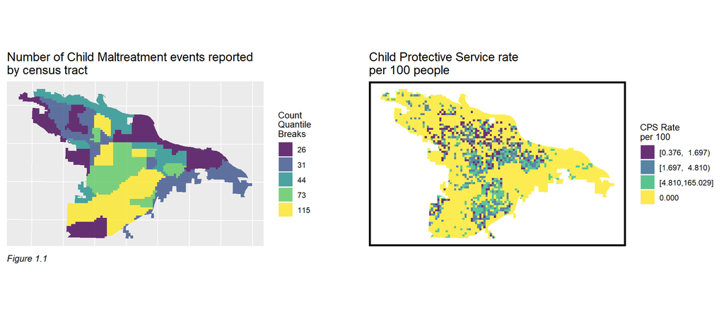

## 1.2 Exploratory Analysis

In this section, we derive a number of descriptive insights from our data. To begin, maltreatment events across space and time are visualized and we discuss some of the possible selection bias in the data. Next, hypotheses related to the clustering of maltreatment events across space are presented. Finally, we calculate a series of pairwise correlations between maltreatment and our features.

### 1.2.1 Analysis of maltreatment events over time and space

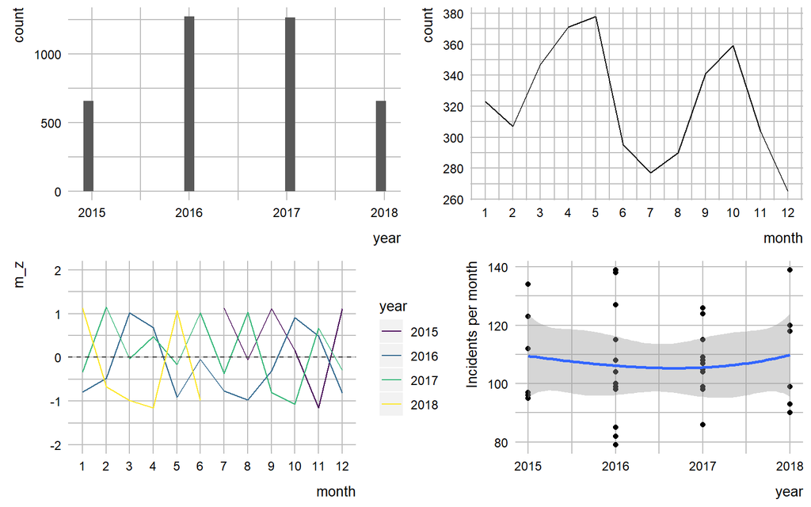

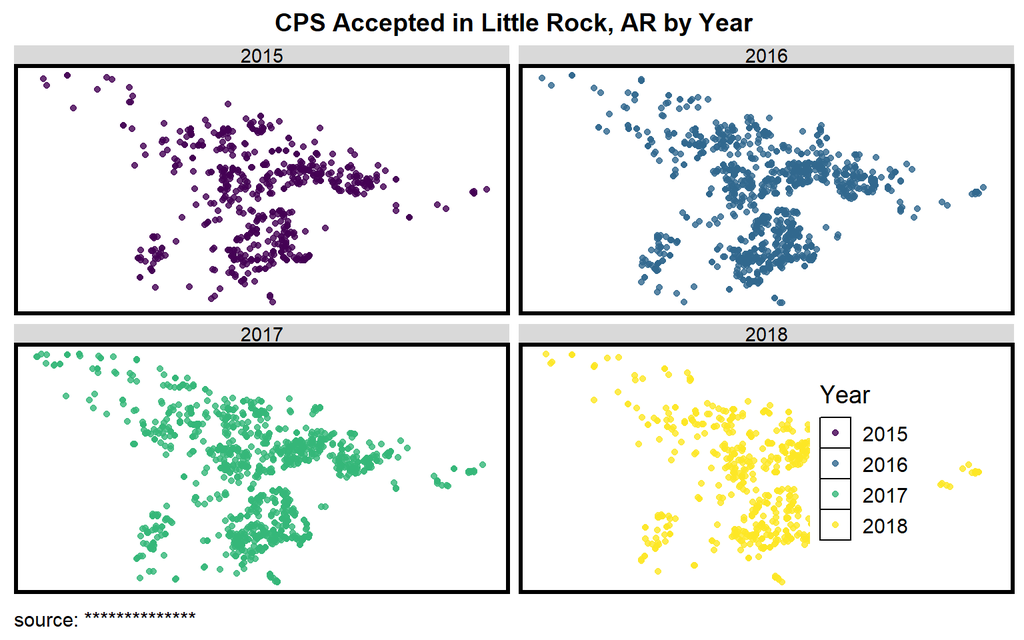

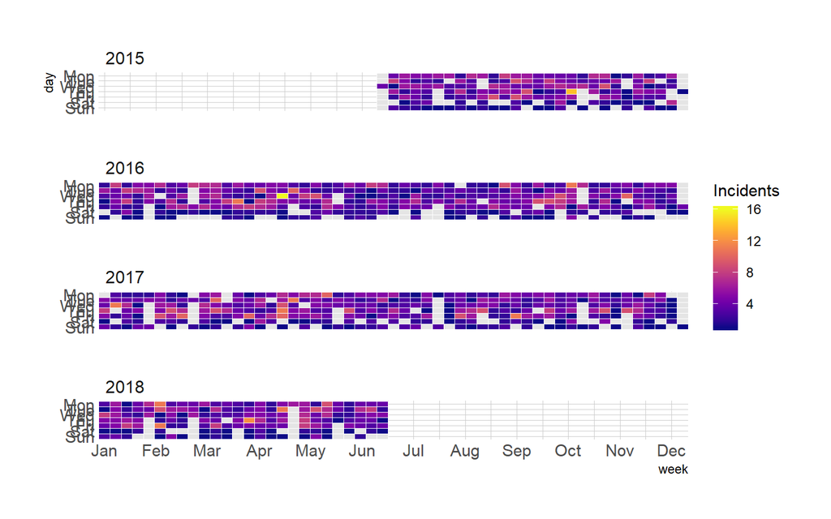

### 1.2.2 Testing maltreatment events for clusters

One overarching assumption behind our model is that maltreatment events are clustered in space. To test this hypothesis, the Local Moran’s I statistic is employed.

The Local Moran’s I statistic asks if the local distribution in the rate of maltreatment events, defined by a spatial weights matrix, is more clustered than we would expect due to random chance alone. The next figure plots the Local Moran’s I results. The first panel shows the count of maltreatment events; Panel 2 shows the Local Moran’s I value; and Panel 3 shows areas that exhibit statistically significant clustering. Panel 3 shows areas that resemble discrete clusters of maltreatment in space.

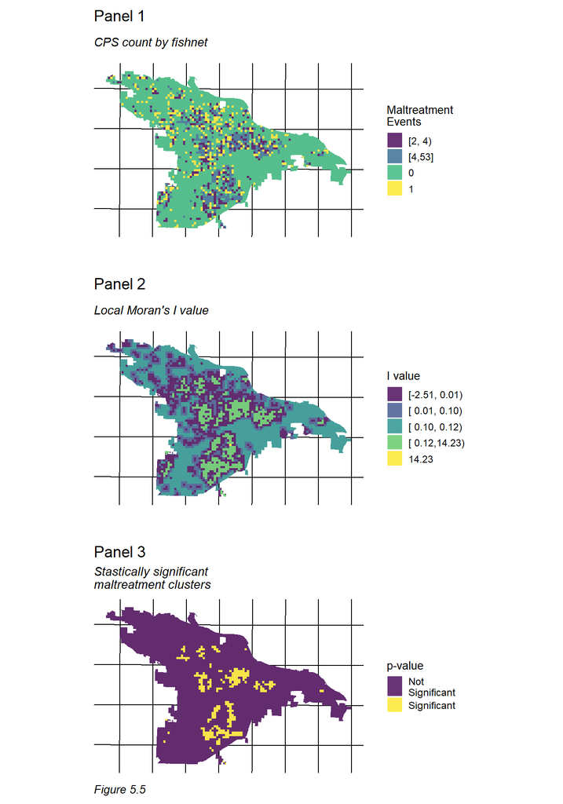

## 1.3 Feature Engineering

### 1.3.1 Pairwise correlations

In the Feature Engineering phase, we create many features from the available data on crime, built environment factors and census data. The two figures below visualize pairwise correlations for the most correlative risk and protective factors respectively. Note the correlation coefficients associated with maltreatment count (`cps_net`) and maltreatment rate (`cps_rate`). The colors of the plot vary with the strength of the correlations, either positive or negative.

There are 3 different prefixes associated which each type of feature. `NN` refers to features calculated by taking the average distance between a fishnet grid cell and its $n$ nearest risk/protective factor neighbor. `ed` refers to the Euclidean distance between a fishnet grid cell and its 1 nearest risk/protective factor neighbor. `agg` refers to the count of risk/protective factor events in a given fishnet grid cell.

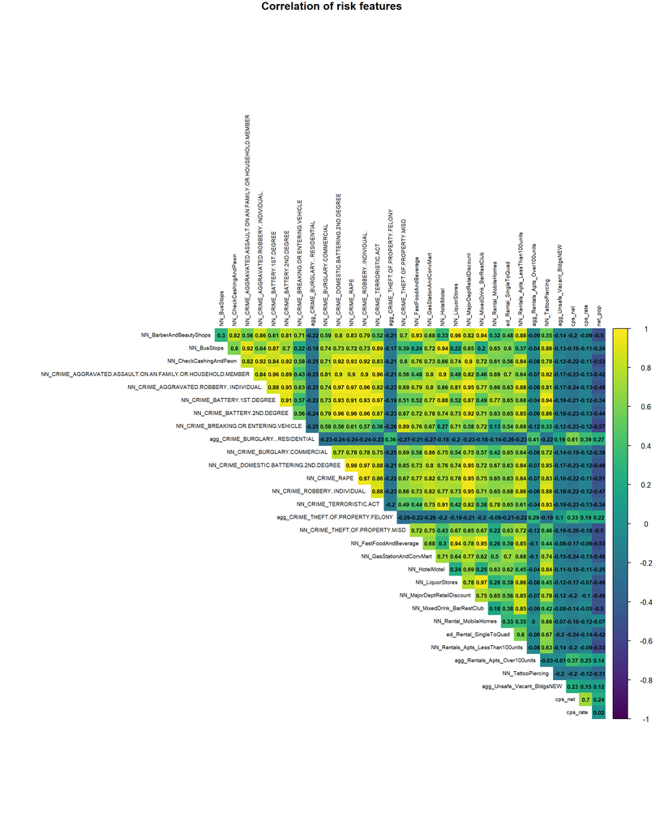

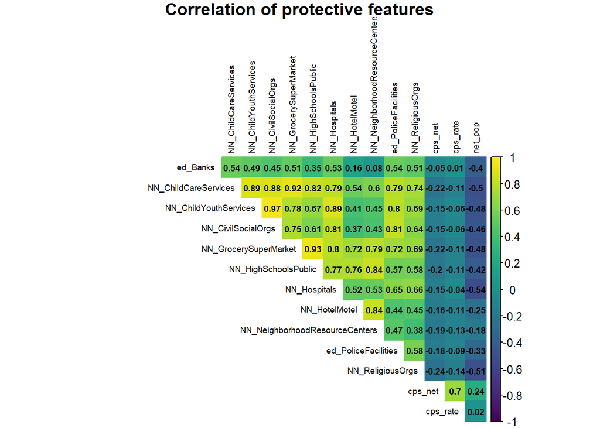

## 1.4 Model Fitting

### 1.4.1 Model fitting & stacking

Model ‘fitting’ describes the process by which a statistical algorithm learns about maltreatment risk by relating the interaction of risk/protective factors to maltreatment events across space. Once a model is fit and validated, the learned pattern is applied back to the contributing features in each fishnet cell to predict the count of maltreatment events across space. This prediction highlights areas where maltreatment is present but unreported.

The first step in the model building process is to select the top few most statistically important risk and protective feature sets. We select across the different feature types (Euclidean distance, average nearest neighbor distance, and aggregate counts) based upon statistical correlation. These features make up the final feature sets, which are then subjected to our models.

Three different algorithms are fit modelling different aspects of the spatial process and then combined into a fourth ‘meta-model’. The three individual models are a Poisson Generalized Linear Model (Poisson GLM), a Random Forest model, and a Spatial Durbin Model (SDM). The final prediction of maltreatment events is produced from the meta-model which is created by applying the Random Forest algorithm to the predictions made by the sub-models. The use of three different model algorithms is an effort to understand different aspects of the highly complex system that contributes to the observation of a maltreatment event.

At each stage in this process, models are fit using a ‘k-fold cross validation’ routine (kFCV). kFCV splits the data into spatially explicit groups, in this case tracts, fits the models to all but $1/k$-th of the groups, and predicts maltreatment event counts for the left out folds of groups. This process, explained in greater detail below, tests how well the models generalize across neighborhoods. Below we explain the three sub-models and their inclusion in the final meta-model as well.

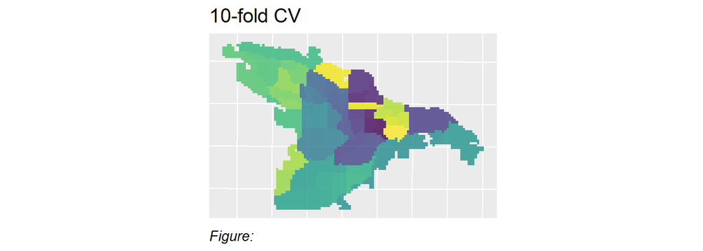

*Poisson GLM*

The Poisson GLM model, fit with the base R `glm` function, is an adaptation of linear regression that accounts for the characteristics of count data. The adaptations include modeling the residuals as Poisson distributed and transforming the linear model with a natural log function. As a result, the predictions from a Poisson model are positive and represent mean expected counts conditional on the contributing risk or protective features for each fishnet grid cell. In the meta-model, Poisson GLM predictions represent a linear model of a Poisson distributed count process.

**Note: The Poisson GLM model is not an optimal choice as we have a modertaely high-dimensional feature space, so it runs into problems of rank-deficiency and multicollinearity. In simple words, rank deficiency happens when the design matrix has less than full rank, leading to lack of unique solutions for the GLM, and multicollinearity implies columns of $X$ matrix exhibiting high-degree of correlation, leading to inflated variance of the parameter estimates and instability. One fix is using a penalized regression that puts a budget on the parameter vector in the GLM framework, such as LASSO or Elastic Net, that cures these issues to some extent.**

*Random Forest*

In this study, the Random Forest algorithm is fit using the `ranger` library. The Random Forest algorithm builds a series of decision tree models to learn the relationship between maltreatment and exposure variables. The stochastic approach to sampling from observed data ensures that each individual tree is different from the next. The Random Forest provides a ‘wisdom of many’ approach, contributing non-linear interactions between maltreatment and the corresponding features to the final meta-model.

*Spatial Durbin Model*

To model spatial interrelationships - also referred to as ‘spatial autocorrelation’ - a Spatial Durbin Model (SDM) is fit using the `errorsarlm` function of the `spdep` package in R. In the setting of this study, the interpretation of this model is that the rate of maltreatment events is affected by both the exogenous exposure factors as well as neighboring rates of maltreatment. Further, this model assumes that there may be latent features that impact the model errors but are not accounted by the exposure features. The key model input of spatial autocorrelation is a spatial weights matrix relating maltreatment in a given grid cell to its neighbors. Modeling the underlying spatial maltreatment process provides a powerful predictive story when input into the final meta-model. It is important to note that the SDM is not fit with the 10FCV method due to the complications of subsetting a spatial weights matrix in a cross-validation setting.

*Meta-Model*

The final maltreatment count predictions are generated from a meta-model which combines predictions from the three sub-models. The process to combine the three models is straightforward; as the predicted counts from each sub-model are used as input features of a new model fit with the Random Forest algorithm. Often referred to as model ‘stacking’, this technique seeks to average out the variance in the three separate models. To reduce the risk of over-fitting, the stacked meta-model is fit and predicted using the same 10FCV routine as the sub-models.

### 1.4.2 Model validation

Assessing the accuracy and spatial generalizability of model predictions is crucial when considering how to embed this model in the provision of child welfare services. A variety of approaches are used for model validation including k-fold cross validation (kFCV) and assorted goodness of fit metrics. Some of these metrics are statistical in nature, while others measure goodness of fit across space.

*Goodness of fit metrics*

Model error is defined simply as the difference between the observed count of maltreatment events and the predicted count for each grid cell. Complicating matters is that 297 models yields more than 567,000 grid cell level predictions. We derive several statistics to summarize and aggregate these errors in order to judge models and compare across them. We describe each below:

The Mean Absolute Error or MAE, measures the average absolute difference between the observed and predicted values. An example interpretation of MAE is that, ‘on average, the model is off by plus or minus 1.67 events’. MAE is simple to interpret in a policy context, however, it comes with some drawbacks, namely that the direction of the error is unknown and that every error is assumed to have the same severity. The MAE assumes that an error between a predicted count of 5 and an observed count of 7 events should be considered the same as an prediction of 23 and an observed value of 25 events. This metric is used here due to its obvious interpretation and common usage in the assessment of predictive models.

The second goodness of fit metric used in this study is called the Logarithmic Score. This metric is not as straightforward as the MAE, but it has qualities that make is well-suited to count-based predictions. The intuition of the Logarithmic Score is as follows: ’What is the likelihood of the observed count given the predicted count. More descriptively stated: if the model predicts 10 events and the observed count is 7 events, then what is the probability of observing those 7 events if the prediction of 10 is indeed the correct number. In this way, the Logarithmic Score measures the deviance between the predicted and observed counts. Specifically, this is measured by calculating the probability density of the observed value from a Poisson distribution centered on the predicted value. The goodness of fit measures below report the negative log of the probability density so that the value should always be minimized. In the results portion of this report, the Logarithmic Score is converted back to a probability and aggregated. The result is a score that is interpreted as the ’average likelihood that the observed counts are true given the predicted maltreatment counts. Closer to one means a higher relative likelihood, 0.5 equates to maximum uncertainty, and a value near zero signifies very little likelihood.

### 1.4.3 Accuracy and generalization tradeoff

The purpose of the 10FCV and the goodness of fit metrics is to assess model errors on average and across space. A model that perfectly predicts the observed event counts for each fishnet grid cell would be very accurate, but would not generalize well to other cells because exposure changes across the city. Conversely, a model that predicts the same count of maltreatment events for every cell would generalize well, but not be relevant to the conditions of any one cell. 10FCV and associated metrics help establish a balance between model accuracy and model generalization. Given the purpose of this study, it is important to create a model that is accurate enough to give confidence, but general enough to be applicable in areas where few cases are documented.

## 1.5 Results

### 1.5.1 Average goodness of fit results

The table below displays the goodness of fit metrics for each of the sub-models and the meta-model. Mean and standard deviation of different metrics are calculated. Means are taken to describe relative goodness of fit across each held out neighborhood. Standard deviations are taken to describe the variation in goodness of fit across each held out neighborhood. If the model generalizes well across neighborhoods, then the standard deviation should be relatively low.

| Model Name | R2_mean | R2_sd | MAE_mean | MAE_sd | RMSE_mean | RMSE_sd | logdev_mean | logdev_sd |
| --- | --- | --- | --- | --- | --- | --- | --- | --- |
| GLM - Poisson | 0.331 | 0.114 | 1.166 | 0.416 | 6.452 | 8.966 | 0.583 | 0.066 |
| Meta-Model | 0.438 | 0.131 | 0.930 | 0.229 | 2.251 | 0.570 | 0.620 | 0.071 |
| Random Forest | 0.391 | 0.107 | 1.072 | 0.221 | 2.362 | 0.576 | 0.540 | 0.065 |
| Spatial Durbin - sqrt | 0.434 | NaN | 0.803 | NaN | 2.348 | NaN | 0.693 | NaN |

R2 or R Squared is a traditional measure of goodness of fit. Although typically not used to evaluate count outcomes, we include it here because it will be familiar to many readers.

RMSE or Root Mean Squared Error is the standard deviation of the prediction error. Like MAE, RMSE is reported on the scale of the dependent variable, but it varies in that the metric is weighted heavily by errors of high magnitude.

For the Logarithmic Score (logdev) the mean is 0.62 with a standard deviation of 0.071. This equates to a 95% confidence interval between 0.558 and 0.682 for the population average. The intuition of this result is that on average, the probability that the model estimates are correct given the documented maltreatment counts is between 0.558 and 0.682. While the population average of errors from independent LOGOCV estimates is helpful for assessing how the model generalized, it is equally important to know how these errors are distributed both statistically and across space.

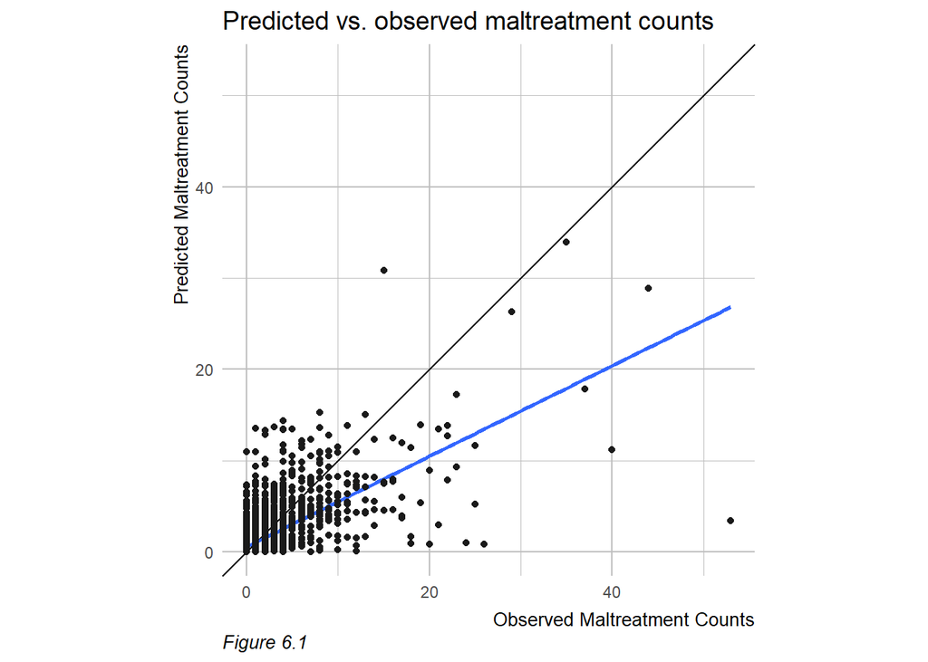

Next figure plots the log-deviance and MAE by the deciles for a visual comparison between the implemented methods.

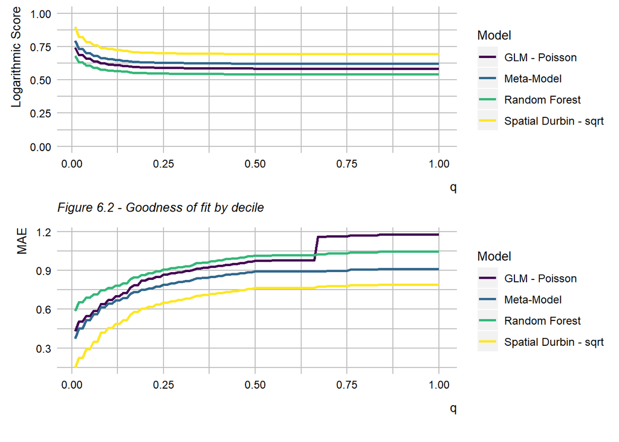

### 1.5.2 Predicted Values and MAE maps

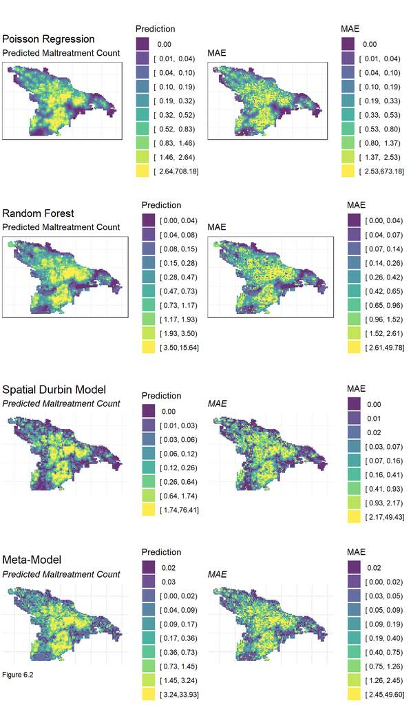

### 1.5.3 Generalizability

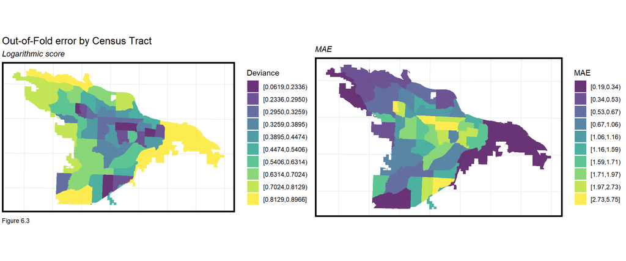

### 1.5.4 Random Forest: Feature importance

Next, we try to get under the hood of the model. We do this first, by visualizing feature importance. The below plot visualizes ‘feature importance’ for the Random Forest sub-model, showing which features make the greatest contribution in predicting maltreatment. We caution the reader to consider these relationships the result of correlation, not causation.

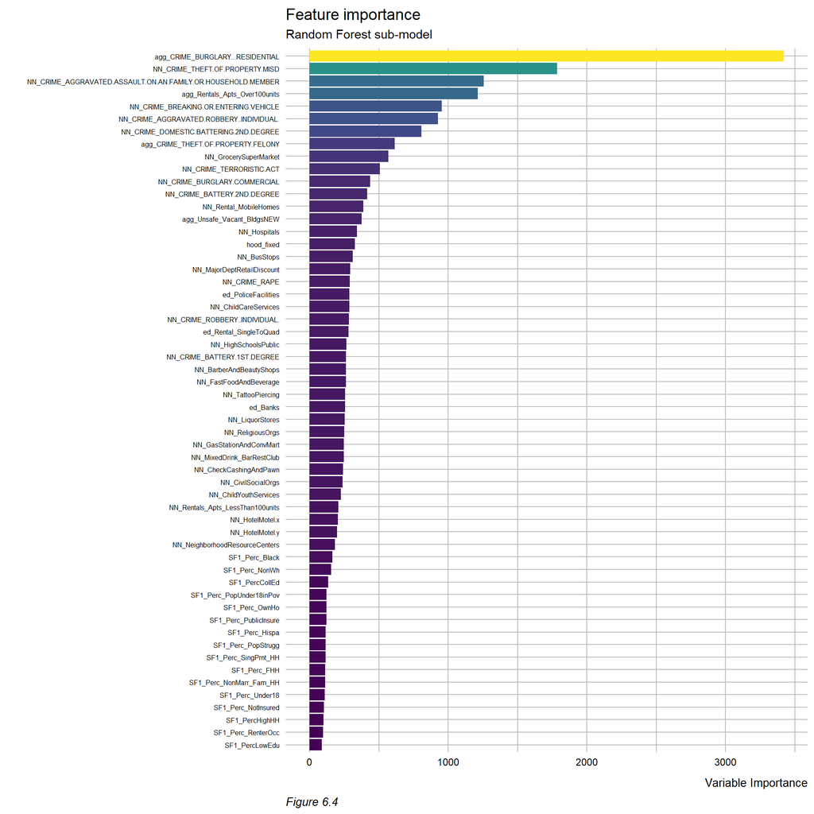

### 1.5.5 Poisson GLM: Coefficients

For a Poisson GLM, the exponents of coefficients are equal to the incidence rate ratio (relative risk).

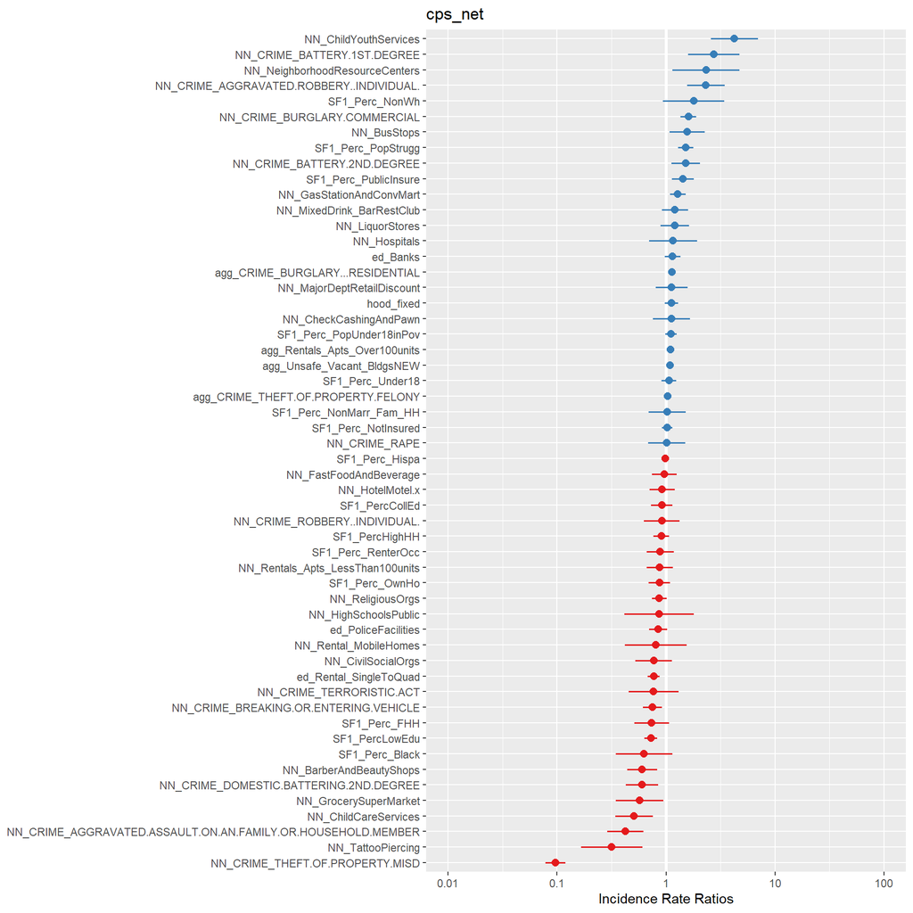

## 1.6 ACS Variables: Stat Area Category Plot

We looked at poverty (population struggling) and non-whites rates by census tracts, classify by quantiles, and plot the spatial distribution (here ‘0’ is less and ‘1’ is more).

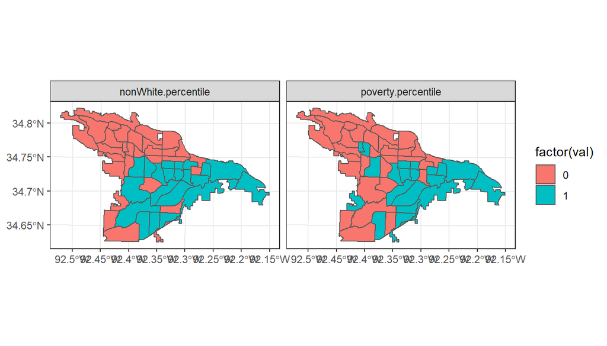

### 1.6.1 Census-tract typology comparison

#### 1.6.1.1 Model Errors by Poverty and Non-white percentage

Next, we aggreate mean errors to statistical areas (med_dev, and med_MAE), aggregate sum of Child maltreatment incidents (med_CPS) to statarea, and (a) group by poverty (pop-struggle) and get median of stat-area aggregate errors, and (b) group by nonwhite and get median of statarea aggregate errors.

Two census attributes are selected for these purposes including percent living below poverty and percent non-white.

| poverty.percentile | med_dev | med_MAE | med_CPS |
| --- | --- | --- | --- |
| 0 | 0.540 | 1.05 | 1800 |
| 1 | 0.415 | 1.71 | 2026 |

| nonWhite.percentile | med_dev | med_MAE | med_CPS |
| --- | --- | --- | --- |
| 0 | 0.507 | 1.091 | 1465 |
| 1 | 0.398 | 1.710 | 2361 |

## 1.7 Comparing meta-model predictions to Kernel Density

Perhaps the strongest method for assessing the usefulness of a predictive model is to compare its predictive power to that of the current resource allocation strategy. Here we compare our model to another common spatial targeting algorithm - Kernel Density Estimation (KDE).

KDE is a simple spatial interpolation technique that calculates ‘predicted risk’ by taking a weighted local density of maltreatment events. No risk/protective factors are used and no measures of statistical significance can be calculated. To compare between the meta-model predictions and KDE, predictions from both are divided into five risk categories for the purposes of comparison. We then overlay held out maltreatment events that were not used to fit the original model, and calculate the percent of observed maltreatment events that fall into each predicted risk category.

Figure 1.5 maps the comparison. The KDE clearly picks up the main areas of recorded events, but also interpolates high predictions for maltreatment in the areas between and beyond. The meta-model is far more targeted.

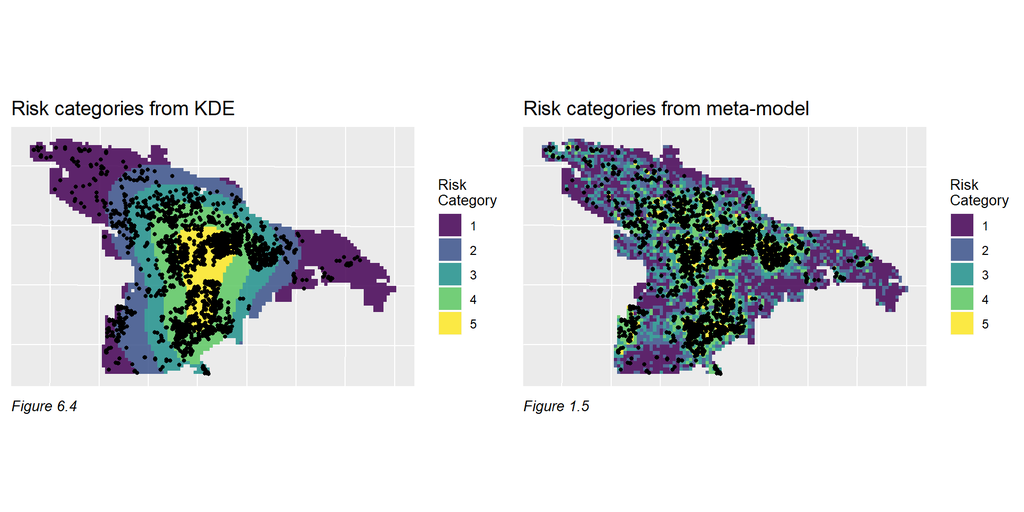

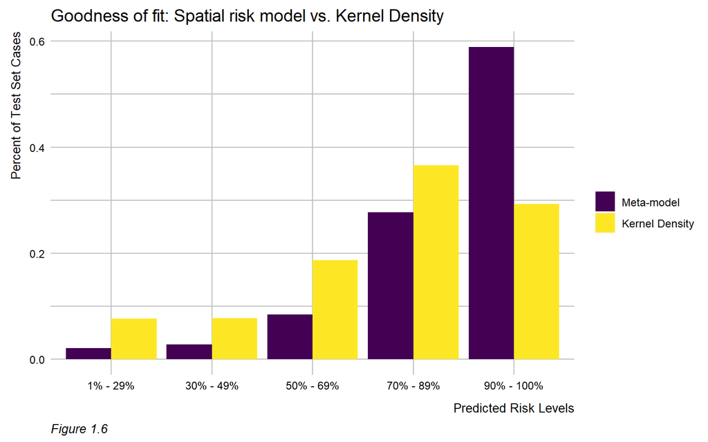

# 2 Align

## 2.1 Risk category population totals

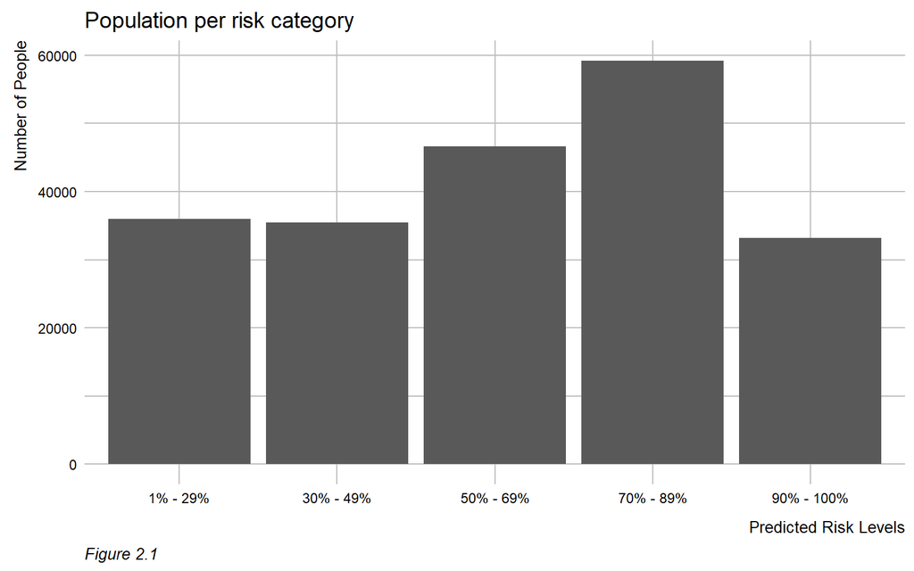

## 2.2 Is poverty related to predicted maltreatment events?

Figure 2.2 maps the weighted poverty rate by fishnet grid cell. How does the distribution of poverty relate to maltreatment events?

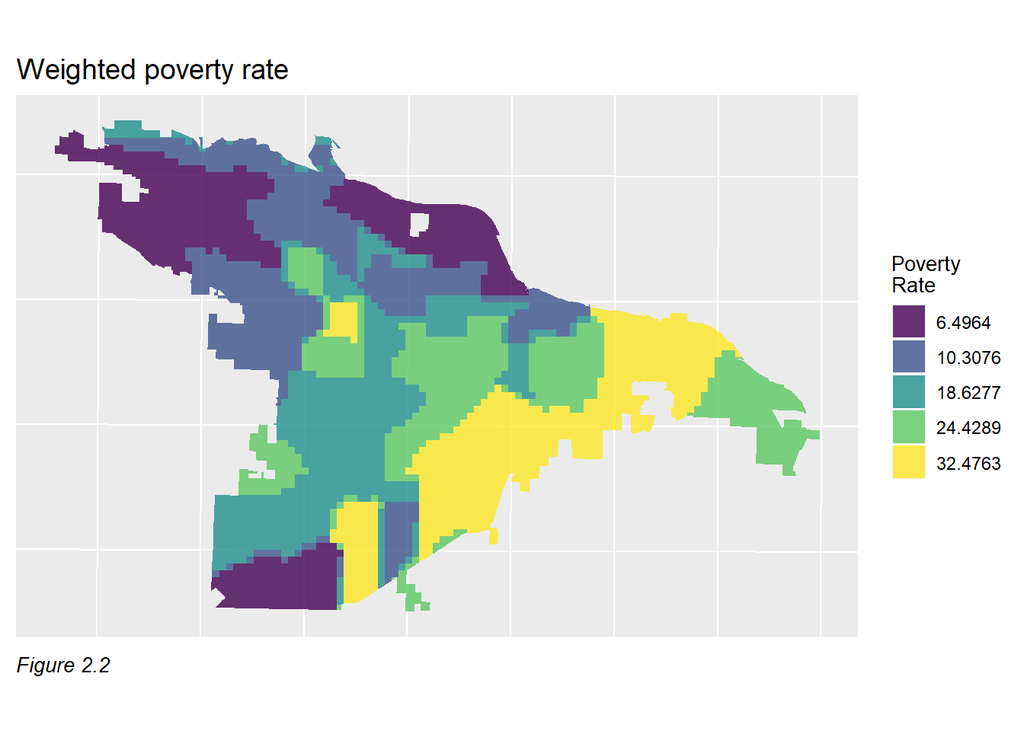

Figure 2.3 illustrates the relationship between poverty rate and predicted maltreatment count. The scatter plot shows that the correlation between poverty and predictive risk is marginal. This visual relationship is confirmed by a correlation coefficient of 0.15. The weak relationship persists even when the zero count grid cells are removed.

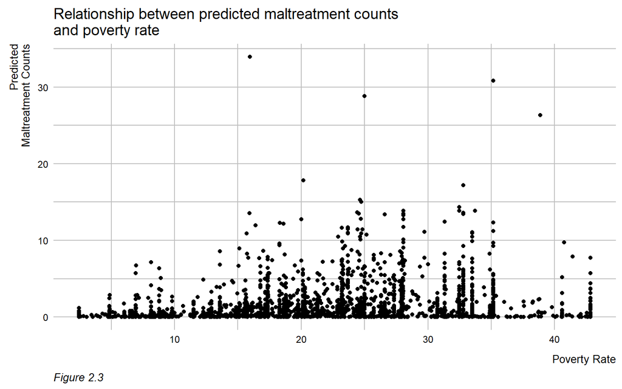

## 2.3 Maltreatment risk and child fatalities

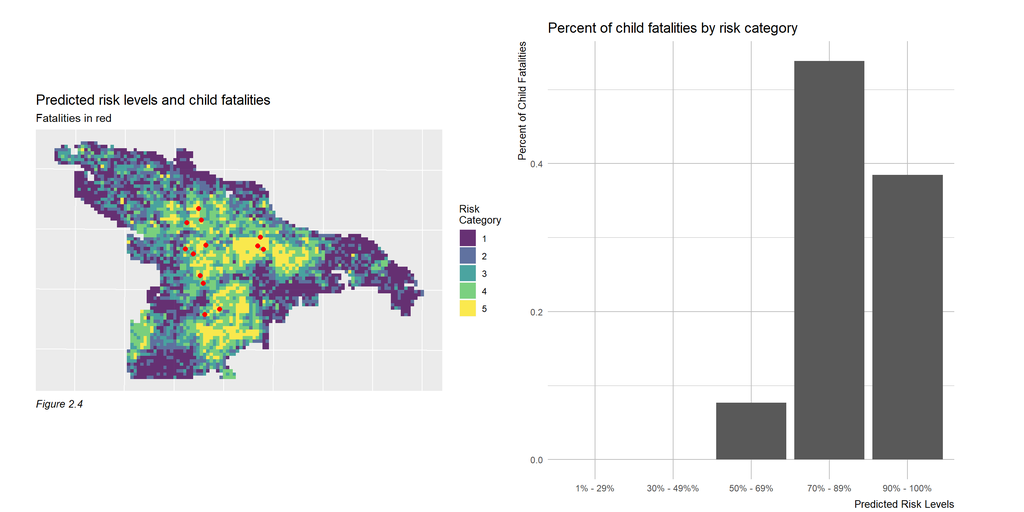

## 2.4 Assign risk scores to protective land uses (DCFS facilities)

The maltreatment predictions suggest where education, outreach, and prevention efforts should occur. What resources are available at these locations? We answer this question using some of the original protective factors data gathered for the predictive model. Stakeholders can replicate this approach on a more finite list of sites that could host these interventions.

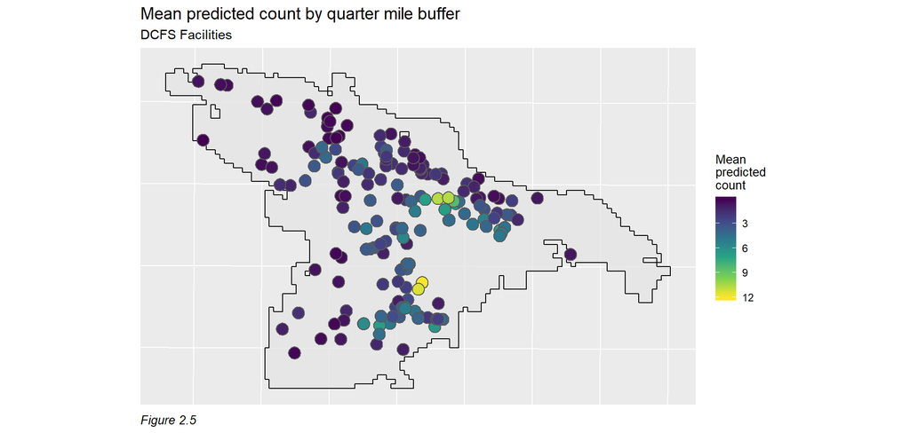

The following table lists the ten most optimally located DCFS facilities based on mean predicted count of maltreatment events within a quarter mile.

| FacilityNa | FacilityTy | PhysicalAd | Mean_Predicted_Count |
| --- | --- | --- | --- |
| Kennedy Headstart | Child Care Center | 4901 West 65th Street | 12 |
| Above And Beyond Child Care | Child Care Center | 80 Westminister | 11 |
| Buttons & Bows Learning Center Inc | Child Care Center | 4124 West 11th Street | 11 |
| Loving Care DCFH | Registered Child Care Family Home | 3505 West 10th | 11 |
| Redeemed for Christ | Child Care Center | 3105 W 12TH ST | 8 |
| Washington Magnet School | Child Care Center | 2700 South Main Street | 7 |
| Lrsd Care Program Washington Elementary | Child Care Center | 2700 South Main street | 7 |
| Stephens Elementary | Child Care Center | 3700 West 18th Street | 7 |
| In A Childs World | Child Care Center | 9420 Chicot Road | 7 |
| From A to Z Preschool | Child Care Center | 4923 W 12th Street | 7 |

This process can be repeated for a specific list of sites, e.g. we can calculate relative measure of risk exposure for Child Care Centers.

## 2.5 Assign risk scores to protective land uses (childcare and resource centers)

**Figure 2.6 plots the relative measure of risk exposure for quarter mile buffers around child care centers.**

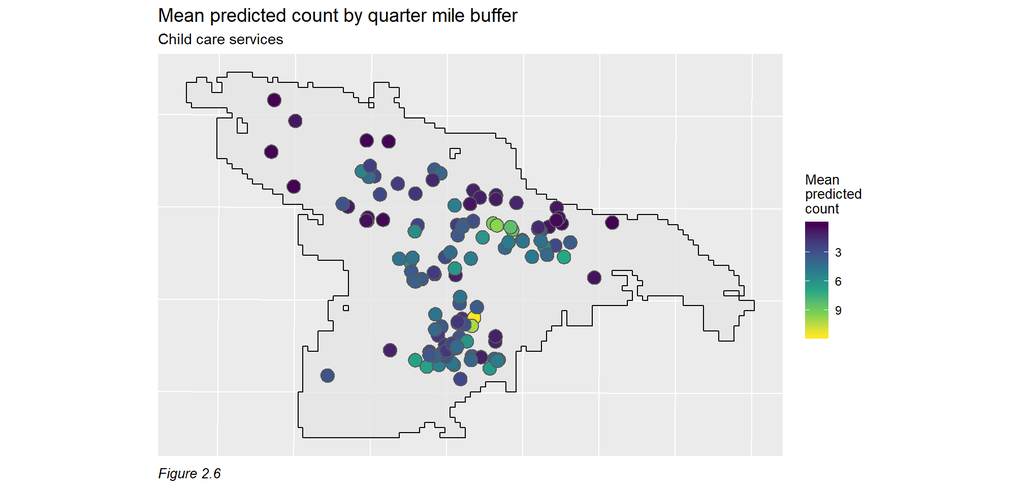

The following table lists the 5 most optimally located childcare facilities based on mean predicted count of maltreatment events within a quarter mile.

| Company | address | Mean_Predicted_Count |
| --- | --- | --- |
| TOUCHED BY AN ANGEL | 6402 BUTLER RD # E | 12 |
| KINDLE LOVIN CARE | 3914 W 12TH ST | 10 |
| ABOVE & BEYOND CHILD CARE CTR | 80 WESTMINISTER DR | 10 |
| BUTTONS & BOWS LEARNING CTR | 4124 W 11TH ST | 9 |
| YOUNG’S DAYCARE CTR | 1314 BOOKER ST | 9 |

**Figure 2.7 plots the relative measure of risk exposure for quarter mile buffers around neighbourhood resource centers.**

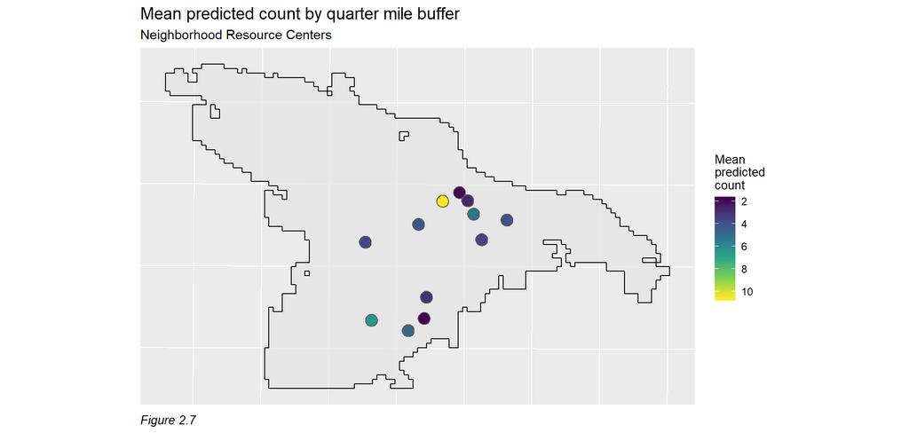

The following table lists the five most optimally located neighbourhood resource centers based on mean predicted count of maltreatment events within a quarter mile.

| Name | Address | Mean_Predicted_Count |
| --- | --- | --- |
| Willie L Hinton Neighborhood Resource Center | 3805 W 12th Street | 11 |
| West Baseline Neighborhood Resource Center | 9209 Mann Road | 7 |
| Wright Avenue Neighborhood Resource Center | 1813 Wright Avenue | 5 |
| Southwest Little Rock Neighborhood Resource Center | 5621 Valley Drive | 5 |
| Oak Forest Neighborhood Resource Center | 2823 Tyler Street | 4 |

## 2.6 Supplementary Material

### 2.6.1 Correlation

#### 2.6.1.1 Positively correlated variables

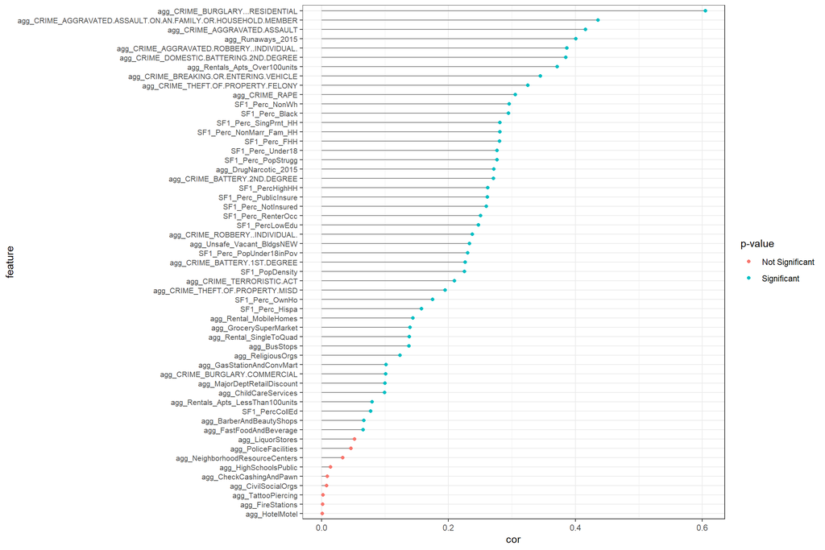

#### 2.6.1.2 Negatively correlated variables

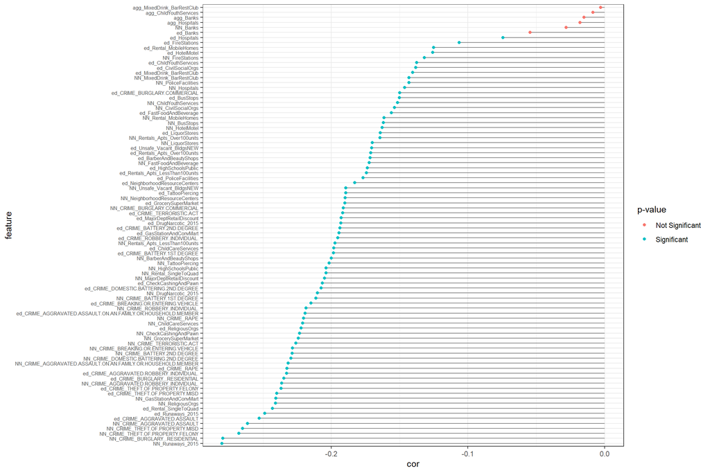

### 2.6.2 Chossing a fishnet grid size

```
500
1000
1500
```

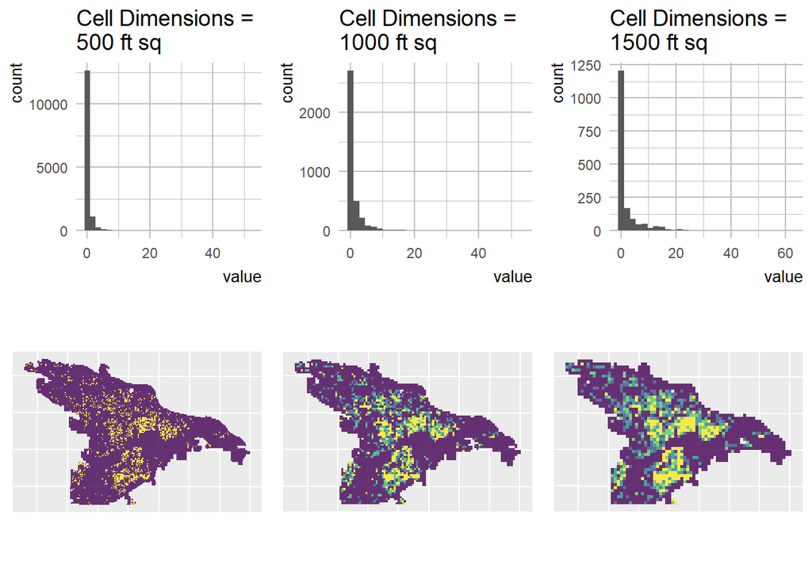

### 2.6.3 Goodness-of-fit Tests

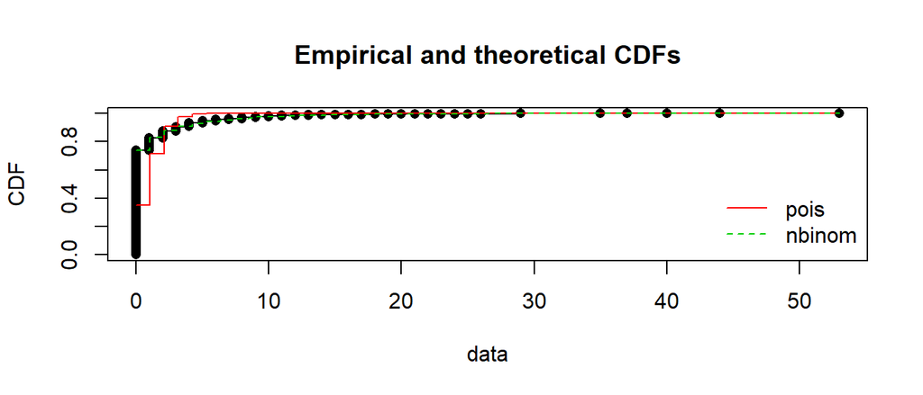

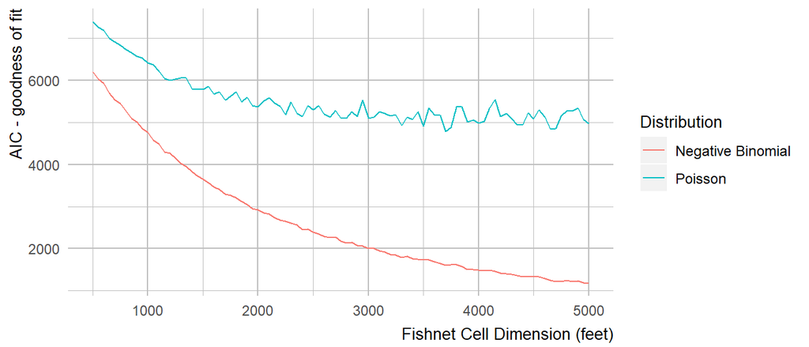

### 2.6.4 Tract fixed effects

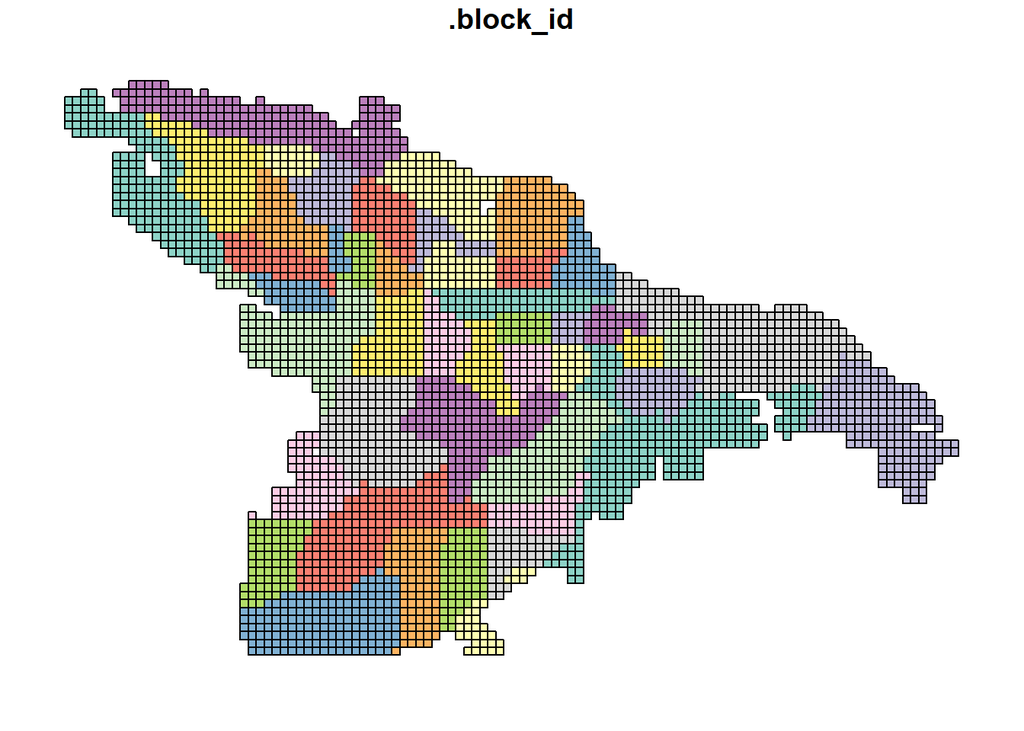

## 2.7 Appendix : R Codes

```r
if(T){
  library("sf")            # Spatial data objects and methods
  library("mapview")       # Interactive Map Viewing
  library("ggmap")         # ggplot2 addon for base maps
  library("cowplot")
  library("spatstat")      # KDE and other spatial functions
  library("raster")        # cell-based spatial operations
  library("tidyverse")     # data manipulation framework
  library("Hmisc")         # using cut2() functions for ggplot legends
  library("fitdistrplus")  # Distribution fitting functions
  library("lubridate")     # Power tools for handling dates
  library("tidycensus")
  library("lwgeom")
  library("Hmisc")
  library("hrbrthemes")
  library("gridExtra")
  library("patchwork")
  library("spdep")         # KNN functions
  library("foreach")
  library("doParallel")
  library("corrplot")
  library("ranger")        # randomforest implimentation
  library("glmnet")        # for Ridge and Lasso Regression
  library("knitr")         # for kable table
  library("kableExtra")
  library("FNN")           # KNN for CPS vs. NN plots
  library("groupdata2")
  library("htmltools")
  library("viridis")
  library("viridisLite")
}
```

```r
mapTheme <- function() {
  theme(
    plot.title = element_text(size = 14, family = "sans", face = "plain", hjust = 0),
    plot.subtitle=element_text(size = 11, family = "sans", hjust = 0),
    plot.caption=element_text(size = 10, family = "sans", face = "italic", hjust = 0),
    axis.text = element_blank(),
    axis.title.x = element_blank(),
    axis.title.y = element_blank(),
    axis.ticks = element_blank(),
    axis.line = element_blank(),
    legend.title = element_text(size = 10, family = "sans"),
    legend.text = element_text(size = 9, family = "sans"),
    panel.border = element_blank()
  )
}

plotTheme <- function() {
  theme(
    plot.title = element_text(size = 14, family = "sans", face = "plain", hjust = 0),
    plot.subtitle=element_text(size = 11, family = "sans", hjust = 0),
    plot.caption=element_text(size = 10, family = "sans", face = "italic", hjust = 0),
    axis.title.x = element_text(size = 10, family = "sans", face = "plain", hjust = 1, vjust = -0.5),
    axis.title.y = element_text(size = 10, family = "sans", face = "plain", hjust = 1, vjust = 1),
    axis.text = element_text(size = 7, family = "sans", face = "plain"),
    panel.background = element_blank(),
    panel.grid.minor = element_line(colour = "gray"),
    panel.grid.major = element_line(colour = "gray"),
    axis.ticks = element_blank(),
    legend.title = element_text(size = 10, family = "sans"),
    legend.text = element_text(size = 9, family = "sans"),
    axis.line = element_blank()
  )
}
```

```r
if(T){
  mapviewOptions(basemaps = c("Stamen.TonerLite", "OpenStreetMap.DE"))
  base_dir = "C:/Users/jd033/Box/LR-Project"
  fishnet_grid_dim = 1000
  k_direction = 8 # 4 = rook, 8 = queen
  k_nearest_neighbors = 5
  # Either k (e.g. 5 or 10) or "LOOCV"
  n_folds = "LOOCV"
  # threshold quntile for statArea grouping
  stat_area_quantile = 0.60
  # Number of simulations for CPS vs. NN
  simulations = 1000
  # Number of neighbors for CPS vs. NN
  k = 5
  # random seed
  set.seed(11235)
}
```

```r
## Source

source('C:/Users/jd033/Box/Child Maltreatment/R-codes/FUNCTIONS_VAPAP_LR.R', echo = FALSE, keep.source = TRUE)
source('C:/Users/jd033/Box/Child Maltreatment/R-codes/FEA_CREATE_VARIABLES_LR_2.R', echo = TRUE, keep.source = TRUE)

## Can be also loaded via
# load("Rdata/source_file_objects.RData")
```

### 2.7.1 LR Tracts

```r
## LR tracts data
lr_tract = var_list[["LR_Tracts_Working51"]]

TRACT_AREA_plot <- lr_tract %>%
    ggplot(aes(fill = Area)) +
    geom_sf(color = NA) +
    coord_sf(crs = 2765) +
    scale_fill_viridis_c(option = "plasma") +
    labs(title = "Area")

lr_tract_diss <- lr_tract %>%
  mutate(dissolve = 1) %>%
  # get rid of slivers
  st_buffer(., dist = 0.1) %>%
  group_by(dissolve) %>%
  summarise()

lr_rast_SP <- raster(as(lr_tract_diss, "Spatial"), nrows = 2000, ncol = 2000)
```

### 2.7.2 Basemap

```r
var_list[["CPS_Accepted"]] <-  var_list[["CM_LR_Matched_Centerline_3857"]]

idx_2 = which(var_names == "CM_LR_Matched_Centerline_3857")
var_list[[idx_2]] <- NULL

cps_base_map   <- get_stamenmap(bbox = c(left = -92.52091, bottom = 34.62606, right = -92.15494, top = 34.82195),
                                    maptype = "toner-lite")

# ggmap(cps_base_map)

## Alternative

lr_base_map <- st_union(lr_tract) %>%
  ggplot()+geom_sf(aes(), fill = "grey85", color = NA, size = 1) +
  mapTheme()

### get CPS_Accepted values (add 1 column for dissolving)
cps_dissolve <- var_list[["CPS_Accepted"]] %>%
  mutate(value = 1) %>%
  dplyr::select(value)
```

### 2.7.3 Count CPS incidents per net cell

```r
net <- st_make_grid(lr_tract, cellsize = fishnet_grid_dim) #%>%st_transform(2756)

# cps_dissolve %>% st_crs() == lr_tract %>% st_crs()

# count CPS incidents per net cell - really just to get net raster into sf polygon format
net_agg <- aggregate(cps_dissolve, net , sum) %>%
    tibble::rowid_to_column(.,"net_id")

net_agg_vals = net_agg$value[!is.na(net_agg$value)]

# summary(net_agg_vals)

# list of net cells IDs that intersect with Little Rock
net_intersect <- st_intersects(lr_tract, net_agg)

# extract Little Rock net cells based on intersect ID
net_littlerock <- net_agg[unique(unlist(net_intersect)),]
net_hood <- st_join(net_littlerock, lr_tract, largest = TRUE)
listw <- nb2listw(poly2nb(as(net_littlerock, "Spatial"), queen = TRUE))

## Plot fishnet

net_littlerock$value[is.na(net_littlerock$value)] <- 0

FISHNET_plot <- net_littlerock %>%
  ggplot(aes(fill = value)) +
  geom_sf(color = "grey60") +
  coord_sf(crs = 2765) +
  scale_fill_viridis_c(option = "magma") +
  labs(title = "CM per grid-cell")+
  plotTheme()
```

### 2.7.4 Population and Other Census Data

```r
acs <- var_list[["LR_BG_Tracts_ACS_DataJoined"]]

acs = acs %>% dplyr::select(Incident_C, TotPopSize, NLTotPop, PopDensity,Perc_Under,
                            Perc_Black, Perc_NonWh, Perc_Hispa, Perc_NonMa,
                            Perc_FHH,Perc_SingP,PercLowEdu, Perc_Rente,
                            Perc_PopUn, Perc_PopSt, Perc_NotIn, Perc_Publi,
                            PercHighHH, PercCollEd, Perc_OwnHo)

acs <- acs %>% rename( Incident_Count_sum = Incident_C,
                       Perc_Under18 = Perc_Under,
                       Perc_NonMarr_Fam_HH = Perc_NonMa,
                       Perc_SingPrnt_HH = Perc_SingP,
                       Perc_RenterOcc = Perc_Rente,
                       Perc_PopUnder18inPov = Perc_PopUn,
                       Perc_PopStrugg = Perc_PopSt,
                       Perc_NotInsured = Perc_NotIn,
                       Perc_PublicInsure = Perc_Publi)


acs_pop <- acs %>% dplyr::select(TotPopSize)

## The number 2.29568e-5 is sq ft to acre conversion.
## if you download from ACS using tidycensus, the variable name is "value", here it's TotPopSize.

acs_pop <- acs_pop %>%
  mutate(acre = as.numeric(st_area(acs)*2.29568e-5),
         # acre = units::set_units(acre, acre),
         pop_acre_rate = TotPopSize / acre)


POP_ACRE_RATE_plot <- acs_pop %>%
  ggplot(aes(fill = pop_acre_rate)) +
  geom_sf(color = NA) +
  coord_sf(crs = 2765) +
  scale_fill_viridis_c(option = "magma") +
  labs(title = "Population per acre")+
  plotTheme()
```

```r
net_blocks_intersect <- st_intersection(acs_pop, net_littlerock)

# group by cell and calc block stats.
net_blocks_intersect <- net_blocks_intersect %>%
  mutate(intersect_area_acres = as.numeric(st_area(net_blocks_intersect)*2.29568e-5)) %>%
  group_by(net_id) %>%
  mutate(cnt = n(),
         pcnt_of_block = intersect_area_acres/acre,
         intersect_pop = TotPopSize * pcnt_of_block) %>%
  arrange(net_id)
```

### 2.7.5 Summarize population

```r
## Summarize pop
fishnet_pop <- net_blocks_intersect %>% # xcc
  group_by(net_id) %>%
  summarise(net_pop = sum(intersect_pop)) %>%
  filter(net_pop > 0)   # <-  zeros or no zeros!!!!

BASIC_FISHNET_plot <-fishnet_pop %>%
  ggplot(aes(fill = net_pop)) +
  geom_sf(color = NA) +
  scale_fill_viridis_c(option = "plasma") +
  labs(title = "Net Pop")

######### MAKE NET AND RATE FOR ALL CPS VARS
CPS_vars <- grep("CPS_",names(var_list), value = TRUE)
CPS_agg <- NULL

for(i in seq_along(CPS_vars)){
  var_name <- paste0("net_",CPS_vars[i])
  cat(var_name,"\n")

  CPS_dat <- var_list[[CPS_vars[i]]] %>%
    mutate(value = 1) %>%
    dplyr::select(value)

  fishnet_CPS_var <- aggregate(x = CPS_dat, by = fishnet_pop, FUN = sum) %>%
    st_drop_geometry() %>%
    mutate(Feature = var_name) %>%
    dplyr::select(Feature,value)

  CPS_agg <- rbind(CPS_agg, fishnet_CPS_var)
}

CPS_agg <- CPS_agg %>%
  mutate(id = rep(seq(1:nrow(fishnet_pop)),length(CPS_vars))) %>%
  spread(Feature, value) %>%
  dplyr::select(-id) %>%
  mutate(geometry = fishnet_pop$geometry) %>%
  st_as_sf()

#### Spatial join of fishnet_pop and fishnet_cps to then calculate rate for all CPS features

fishnet_pop_cps <- st_join(fishnet_pop, CPS_agg, join = st_equals) %>%
  mutate_at(vars(paste0("net_",CPS_vars)), funs(rate = ./(net_pop/100)))  %>% # cps per 100 person
  # rename_at(vars( contains( "_rate")), .funs = list(paste("rate", gsub("net_|_rate", "", .), sep = "_"))) %>%
  replace(is.na(.), 0) # replace NA with zero

fishnet_coords <- fishnet_pop_cps %>%
  st_centroid() %>%
  st_coordinates() %>%
  as.matrix()
```

### 2.7.6 CM Count by fishnet

```r
fishnet_pop_cps_cut <- fishnet_pop_cps %>%
  mutate(net_CPS_Accepted = ifelse(is.na(net_CPS_Accepted), 0, net_CPS_Accepted)) %>%
  make_cuts(., "net_CPS_Accepted", cuts = "breaks", n_breaks = 10)

CPS_COUNT_BY_FISHNET_PLOT <- lr_base_map + #ggplot() + #ggmap(cps_base_map) +
  geom_sf(data = ll(fishnet_pop_cps_cut), aes(fill = cut_val), inherit.aes = FALSE, color = NA, alpha = 0.8) +
  labs(title = "CPS count per\nfishnet cell") +
  scale_fill_viridis_d(na.value = NA, option = "D", direction = 1, name = "CPS Count") +
  mapTheme() +
  theme(plot.title = element_text(size = 14, family = "sans", face = "plain", hjust = 0),
        plot.subtitle=element_text(size = 11, family = "sans", hjust = 0),
        plot.caption=element_text(size = 10, family = "sans", face = "italic", hjust = 0),
        axis.line = element_blank(),
        legend.title = element_text(size = 10, family = "sans"),
        legend.text = element_text(size = 9, family = "sans"))
```

```r
fishnet_pop_cps <- fishnet_pop_cps %>% rename(rate_CPS_Accepted = rate)

fishnet_pop_cps_rate_cut <- fishnet_pop_cps %>%
  mutate(rate_CPS_Accepted = ifelse(is.na(rate_CPS_Accepted), 0, rate_CPS_Accepted)) %>%
  make_cuts(., "rate_CPS_Accepted", cuts = "breaks", n_breaks = 10)

CPS_RATE_BY_FISHNET_PLOT <- ggplot() + #ggmap(cps_base_map) +
  geom_sf(data = ll(fishnet_pop_cps_rate_cut), aes(fill = cut_val), inherit.aes = FALSE, color = NA, alpha = 0.8) +
  labs(title = "Child Protective Service rate\nper 100 people") +
  scale_fill_viridis_d(na.value = NA, option = "D", direction = 1, name = "CPS Rate\nper 100") +
  mapTheme() +
  theme(plot.title = element_text(size = 14, family = "sans", face = "plain", hjust = 0),
        plot.subtitle=element_text(size = 11, family = "sans", hjust = 0),
        plot.caption=element_text(size = 10, family = "sans", face = "italic", hjust = 0),
        axis.line = element_blank(),
        legend.title = element_text(size = 10, family = "sans"),
        legend.text = element_text(size = 9, family = "sans"))
```

### 2.7.7 CPS counts by month and year

```r
CPS_Counts_Year_table  <- table(lubridate::year(var_list[["CPS_Accepted"]]$Referral_D))
CPS_Counts_Month_table <- table(lubridate::month(var_list[["CPS_Accepted"]]$Referral_D))
```

### 2.7.8 CPS histogram by date

```r
CPS_by_year <- lubridate::year(var_list[["CPS_Accepted"]]$Referral_D) %>%
  data.frame(year = .)
CPS_HIST_BY_DATE <- ggplot(CPS_by_year, aes(x = year)) +
  geom_histogram() +
  plotTheme()
```

### 2.7.9 CPS points by month plot

```r
months <- c("January", "February", "March", "April",
            "May", "June", "July","August",
            "September", "October", "November", "December")
cps <- var_list[["CPS_Accepted"]] %>%
  mutate(year  = lubridate::year(Referral_D),
         month = lubridate::month(Referral_D),
         month = months[month],
         month = fct_relevel(month, months))

CPS_POINT_BY_MONTH_plot <- ggplot()+#ggmap(cps_base_map) +
  geom_point(data = data.frame(st_coordinates(ll(cps)), year = cps$year),
             aes(x=X, y=Y, color = as.factor(year)), size=1.5, alpha = 0.8) +
  scale_color_viridis_d(name = "Year") +
  labs(title = "CPS Accepted in Little Rock, AR by Year",
       caption = "source: **************") +
  facet_wrap(~year) +
  mapTheme() +
  theme(
    legend.key = element_rect(fill = "white"),
    strip.text = element_text(face = "plain", size = 11),
    legend.position = c(0.85, 0.25) # or "none
  )
```

### 2.7.10 CPS KDE by Year plot

```r
variable = "year"
values <- unique(cps[[variable]])
year_dat <- list()
brks <- 9
window_cps <- get_window(cps, buff_dist = 10000)
for(i in seq_along(values)){
  dat <- filter(cps, !!as.name(variable) == values[i])
  points.ppp <- as.ppp(st_coordinates(ll(dat)),window_cps)
  densityRaster <- raster(density(points.ppp, scalekernel=TRUE, sigma = 0.005))
  dens_data <- gplot_data(densityRaster, maxpixels = 2500) %>%
    mutate(!!as.name(variable) := values[i])
  year_dat[[i]] <- dens_data
}
year_dat <- do.call(rbind, year_dat)

CPS_KDE_BY_YEAR_plot <- ggplot() + #ggmap(cps_base_map) +
  geom_tile(data = year_dat,
            aes(x,y,fill = as.factor(ntile(value,brks)),
                group = !!as.name(variable)), alpha=0.8) +
  scale_fill_viridis_d(name = variable) +
  labs(title = "CPS accepted in Little Rock, VA by year",
       caption = "Figure 5.2") +
  facet_wrap(vars(!!as.name(variable))) +
  mapTheme() +
  theme(
    legend.key = element_rect(fill = "white"),
    strip.text = element_text(face = "plain", size = 11, hjust = 0),
    strip.background = element_rect(fill = "white"),
    legend.position = "none"
  )
```

### 2.7.11 CPS trend by month and year

```r
# CPS_KDE_BY_YEAR_plot

CPS_by_year_month <- st_drop_geometry(var_list[["CPS_Accepted"]]) %>%
  mutate(month = lubridate::month(Referral_D),
         year  = lubridate::year(Referral_D))%>%
  dplyr::select(month, year) %>%
  group_by(month, year) %>%
  mutate(m_count = n()) %>%
  distinct() %>%
  ungroup()

CPS_TREND_BY_MONTH_YEAR_plot <- ggplot(CPS_by_year_month, aes(x = year, y = m_count)) +
  geom_point() +
  geom_smooth(method = lm, formula = y ~ splines::bs(x, 3)) +
  labs(y="Incidents per month") +
  plotTheme()
```